# More on regression

STAT 230

February 14, 2017

Note: the “error=TRUE” above (you need to look at the Rmd file to see it!) is useful for allowing the “knitting” process (making an html or doc or pdf file) to continue past an error and still produce a document.

- Practice quiz solutions will be posted today
- For homework, question about linear vs quadratic is for yearly earnings, not a trick question.

Terminology:

- Simple regression: one explanatory variable
- Multiple regression: more than one explanatory variable

## Something for Valentine’s Day

This is partly for fun and partly to as a review and application of some things we’ve been doing (including merging data sets).

```r
love <- read.csv("http://www.stat.yale.edu/~jtc5/STAT230/data/global-love-ranking.csv", as.is=TRUE)
nations <- read.csv("http://www.stat.yale.edu/~jtc5/STAT230/data/nations2008.csv", as.is=TRUE)

head(love)
```

```
##             country code  love samplesize
## 1       Philippines  PHL 93.3%       2193
## 2            Rwanda  RWA 92.2%       1495
## 3       Puerto Rico  PRI 90.2%        495
## 4           Hungary  HUN 88.9%       1002
## 5            Cyprus  CYP 88.1%        988
## 6 Trinidad & Tobago  TTO 87.6%        506
```

```r
tail(love)
```

```
##        country code  love samplesize
## 131    Belarus  BLR 43.1%       1992
## 132    Georgia  GEO 42.9%       1904
## 133 Kyrgyzstan  KGZ   34%       1969
## 134   Mongolia  MNG 32.3%        928
## 135 Uzbekistan  UZB   32%        962
## 136    Armenia  ARM 29.1%       1954
```

```r
head(nations)
```

```
##   code              country year gdp_percap life_expect population
## 1  AND              Andorra 2008         NA          NA      85616
## 2  ARE United Arab Emirates 2008  69124.396    76.30776    6900142
## 3  AFG          Afghanistan 2008   1283.041    58.22502   26528741
## 4  ATG  Antigua and Barbuda 2008  24723.112    74.97917      85350
## 5  ALB              Albania 2008   8769.094    76.65207    2947314
## 6  ARM              Armenia 2008   7097.912    73.94500    2975029
##   birth_rate neonat_mortal_rate                     region
## 1     10.400                1.8      Europe & Central Asia
## 2     12.423                4.6 Middle East & North Africa
## 3     41.560               39.8                 South Asia
## 4     17.514                6.6  Latin America & Caribbean
## 5     11.561                8.2      Europe & Central Asia
## 6     14.101               10.6      Europe & Central Asia
##                income
## 1         High income
## 2         High income
## 3          Low income
## 4 Upper middle income
## 5 Upper middle income
## 6 Lower middle income
```

```r
dat <- merge(x = love, y = nations[ ,c("code", "gdp_percap")], by="code")
head(dat)
```

```
##   code              country  love samplesize gdp_percap
## 1  AFG          Afghanistan 60.4%       1128   1283.041
## 2  AGO               Angola 61.8%        957   6298.012
## 3  ALB              Albania 63.9%        855   8769.094
## 4  ARE United Arab Emirates 77.3%        961  69124.396
## 5  ARG            Argentina 81.3%       1985         NA
## 6  ARM              Armenia 29.1%       1954   7097.912
```

```r
tail(dat)
```

```
##     code      country  love samplesize gdp_percap
## 128  VEN    Venezuela 81.9%        997  17208.193
## 129  VNM      Vietnam 79.4%       1901   3924.101
## 130  YEM        Yemen 48.4%        959   4128.412
## 131  ZAF South Africa 75.6%       1968  11792.057
## 132  ZMB       Zambia 74.4%       1971   2760.254
## 133  ZWE     Zimbabwe 72.3%       1989   1170.462
```

```r
hist(dat$love) #error
```

```
## Error in hist.default(dat$love): 'x' must be numeric
```

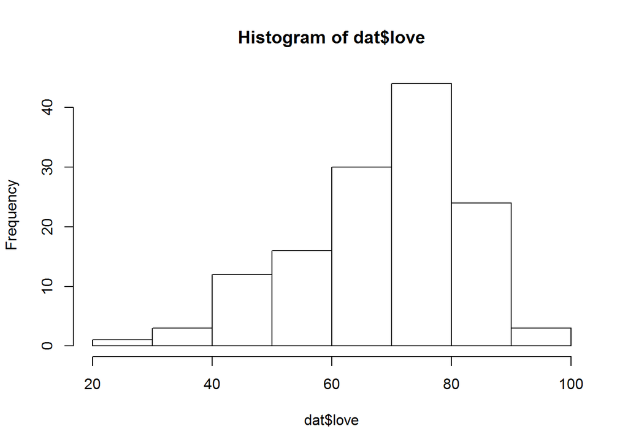

```r
dat$love <- as.numeric(gsub("%", "", dat$love, fixed=TRUE)) # ok without "fixed=TRUE" also
hist(dat$love)
```

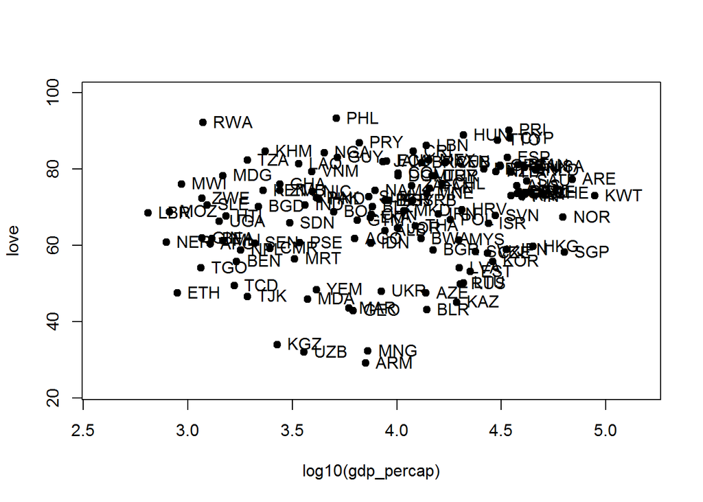

```r
# Doing a plot here with points and also the text codes for countries. The details aren't important and don't bother with them unless you are interested. But the picture is worth making, particularly on Valentine's Day!
xvec <- na.omit(log10(dat$gdp_percap))
L <- min(xvec); U <- max(xvec)
dx <- .1; dy=.1
xlim=c((1+dx)*L-dx*U, (1+dx)*U-dx*L)
L <- min(dat$love); U <- max(dat$love)
ylim=c((1+dy)*L-dy*U, (1+dy)*U-dy*L)

plot(love ~ log10(gdp_percap), data=dat, pch=19, xlim=xlim, ylim=ylim)
text(log10(dat$gdp_percap), dat$love, labels=dat$code, pos=4)
```

Well, linear regression doesn’t seem like it will be all that useful here but let’s run it to take a look.

```r
m <- lm(love ~ log10(gdp_percap), data=dat)
m
```

```
##
## Call:
## lm(formula = love ~ log10(gdp_percap), data = dat)
##
## Coefficients:
##       (Intercept)  log10(gdp_percap)
##            46.708              5.507
```

```r
abline(m)
```

```
## Error in int_abline(a = a, b = b, h = h, v = v, untf = untf, ...): plot.new has not been called yet
```

```r
R <- cor(dat$love, log10(dat$gdp_percap), use="complete")
R^2  # .0481
```

```
## [1] 0.04810577
```

```r
m
```

```
##
## Call:
## lm(formula = love ~ log10(gdp_percap), data = dat)
##
## Coefficients:
##       (Intercept)  log10(gdp_percap)
##            46.708              5.507
```

```r
summary(m) # See the .0481 in the display?
```

```
##
## Call:
## lm(formula = love ~ log10(gdp_percap), data = dat)
##
## Residuals:
##     Min      1Q  Median      3Q     Max
## -38.815  -6.011   2.012   8.720  28.573
##
## Coefficients:
##                   Estimate Std. Error t value Pr(>|t|)
## (Intercept)         46.708      8.587   5.439 2.59e-07 ***
## log10(gdp_percap)    5.507      2.157   2.553   0.0118 *
## ---
## Signif. codes:  0 '***' 0.001 '**' 0.01 '*' 0.05 '.' 0.1 ' ' 1
##
## Residual standard error: 13.05 on 129 degrees of freedom
##   (2 observations deleted due to missingness)
## Multiple R-squared:  0.04811,    Adjusted R-squared:  0.04073
## F-statistic: 6.519 on 1 and 129 DF,  p-value: 0.01184
```

R-squared is two things in simple regression:

- the square of the correlation between x and y
- the “proportion of variability explained by the regression”.

Here R-squared is on 4.8%, nothing to write home about: Although we may “love” the scatterplot, we can’t be very enthusiastic about the power of this regression to predict love from gdp.

## Mammals data set

The morals of this story are

- We can use regression to help us make meaningful comparisons, but “adjusting” or “controlling” for variables. Here we’ll comparing brain mass controlling for body mass.
- We’ll see about `attach` and learn something about how R finds things.

`mammals` is “built in” to R.

```r
head(mammals) # error
```

```
## Error in head(mammals): object 'mammals' not found
```

```r
library(MASS)
head(mammals) # no error; mammals is in the MASS library
```

```
##                    body brain
## Arctic fox        3.385  44.5
## Owl monkey        0.480  15.5
## Mountain beaver   1.350   8.1
## Cow             465.000 423.0
## Grey wolf        36.330 119.5
## Goat             27.660 115.0
```

```r
dim(mammals)
```

```
## [1] 62  2
```

```r
head(mammals)
```

```
##                    body brain
## Arctic fox        3.385  44.5
## Owl monkey        0.480  15.5
## Mountain beaver   1.350   8.1
## Cow             465.000 423.0
## Grey wolf        36.330 119.5
## Goat             27.660 115.0
```

```r
tail(mammals)
```

```
##                    body brain
## Echidna           3.000  25.0
## Brazilian tapir 160.000 169.0
## Tenrec            0.900   2.6
## Phalanger         1.620  11.4
## Tree shrew        0.104   2.5
## Red fox           4.235  50.4
```

```r
plot(brain ~ body) # error
```

```
## Error in eval(expr, envir, enclos): object 'brain' not found
```

```r
plot(brain ~ body, data=mammals) # no error
```

```r
plot(brain ~ body) # still an error
```

```
## Error in eval(expr, envir, enclos): object 'brain' not found
```

`brain` and `body` exist only inside `mammals`. If you want to be able to refer to them without continually writing `mammals` you can use the `attach` function.

```r
attach(mammals)
plot(brain ~ body)
```

Now there is no error because R will look in `mammals` to find the meaning of a name (like `brain`) if the name is not defined in the “global environment”. So having attahed `mammals`, R will look in the “global environment” first, and then mammals, and then… what? The `search` function will tell us the databases R will search, in order:

```r
search()
```

```
##  [1] ".GlobalEnv"        "mammals"           "package:MASS"
##  [4] "package:stats"     "package:graphics"  "package:grDevices"
##  [7] "package:utils"     "package:datasets"  "package:methods"
## [10] "Autoloads"         "package:base"
```

```r
find("brain")
```

```
## [1] "mammals"
```

```r
find("body")
```

```
## [1] "mammals"      "package:base"
```

```r
detach(2)
search()
```

```
##  [1] ".GlobalEnv"        "package:MASS"      "package:stats"
##  [4] "package:graphics"  "package:grDevices" "package:utils"
##  [7] "package:datasets"  "package:methods"   "Autoloads"
## [10] "package:base"
```

```r
brain # no brain now
```

```
## Error in eval(expr, envir, enclos): object 'brain' not found
```

```r
body # still a body in "package:base"
```

```
## function (fun = sys.function(sys.parent()))
## {
##     if (is.character(fun))
##         fun <- get(fun, mode = "function", envir = parent.frame())
##     .Internal(body(fun))
## }
## <bytecode: 0x00000000086ac188>
## <environment: namespace:base>
```

If you use `attach` you should use it with caution and understanding of how R finds things!

OK, back to the data and the question: Which species has the biggest, most impressive brains?

```r
attach(mammals)
brain
```

```
##  [1]   44.50   15.50    8.10  423.00  119.50  115.00   98.20    5.50
##  [9]   58.00    6.40    4.00    5.70    6.60    0.14    1.00   10.80
## [17]   12.30    6.30 4603.00    0.30  419.00  655.00    3.50  115.00
## [25]   25.60    5.00   17.50  680.00  406.00  325.00   12.30 1320.00
## [33] 5712.00    3.90  179.00   56.00   17.00    1.00    0.40    0.25
## [41]   12.50  490.00   12.10  175.00  157.00  440.00  179.50    2.40
## [49]   81.00   21.00   39.20    1.90    1.20    3.00    0.33  180.00
## [57]   25.00  169.00    2.60   11.40    2.50   50.40
```

```r
sort(brain) # just the numbers; I'd like to see the species too
```

```
##  [1]    0.14    0.25    0.30    0.33    0.40    1.00    1.00    1.20
##  [9]    1.90    2.40    2.50    2.60    3.00    3.50    3.90    4.00
## [17]    5.00    5.50    5.70    6.30    6.40    6.60    8.10   10.80
## [25]   11.40   12.10   12.30   12.30   12.50   15.50   17.00   17.50
## [33]   21.00   25.00   25.60   39.20   44.50   50.40   56.00   58.00
## [41]   81.00   98.20  115.00  115.00  119.50  157.00  169.00  175.00
## [49]  179.00  179.50  180.00  325.00  406.00  419.00  423.00  440.00
## [57]  490.00  655.00  680.00 1320.00 4603.00 5712.00
```

```r
head(mammals)
```

```
##                    body brain
## Arctic fox        3.385  44.5
## Owl monkey        0.480  15.5
## Mountain beaver   1.350   8.1
## Cow             465.000 423.0
## Grey wolf        36.330 119.5
## Goat             27.660 115.0
```

```r
head(rownames(mammals))
```

```
## [1] "Arctic fox"      "Owl monkey"      "Mountain beaver" "Cow"
## [5] "Grey wolf"       "Goat"
```

```r
names(brain) <- rownames(mammals)
head(brain)
```

```
##      Arctic fox      Owl monkey Mountain beaver             Cow
##            44.5            15.5             8.1           423.0
##       Grey wolf            Goat
##           119.5           115.0
```

```r
sort(brain)
```

```
## Lesser short-tailed shrew          Little brown bat
##                      0.14                      0.25
##             Big brown bat                Musk shrew
##                      0.30                      0.33
##                     Mouse           Star-nosed mole
##                      0.40                      1.00
##            Golden hamster          E. American mole
##                      1.00                      1.20
##                       Rat           Desert hedgehog
##                      1.90                      2.40
##                Tree shrew                    Tenrec
##                      2.50                      2.60
##                  Mole rat         European hedgehog
##                      3.00                      3.50
##             Water opossum           Ground squirrel
##                      3.90                      4.00
##                    Galago                Guinea pig
##                      5.00                      5.50
##    Arctic ground squirrel              N.A. opossum
##                      5.70                      6.30
##                Chinchilla African giant pouched rat
##                      6.40                      6.60
##           Mountain beaver     Nine-banded armadillo
##                      8.10                     10.80
##                 Phalanger                    Rabbit
##                     11.40                     12.10
##                Tree hyrax              Rock hyrax-a
##                     12.30                     12.30
##                Slow loris                Owl monkey
##                     12.50                     15.50
##     Yellow-bellied marmot                     Genet
##                     17.00                     17.50
##              Rock hyrax-b                   Echidna
##                     21.00                     25.00
##                       Cat                   Raccoon
##                     25.60                     39.20
##                Arctic fox                   Red fox
##                     44.50                     50.40
##                  Kangaroo                    Verbet
##                     56.00                     58.00
##           Giant armadillo                  Roe deer
##                     81.00                     98.20
##                      Goat              Patas monkey
##                    115.00                    115.00
##                 Grey wolf                    Jaguar
##                    119.50                    157.00
##           Brazilian tapir                     Sheep
##                    169.00                    175.00
##             Rhesus monkey                    Baboon
##                    179.00                    179.50
##                       Pig                 Grey seal
##                    180.00                    325.00
##                   Gorilla                    Donkey
##                    406.00                    419.00
##                       Cow                Chimpanzee
##                    423.00                    440.00
##                     Okapi                     Horse
##                    490.00                    655.00
##                   Giraffe                     Human
##                    680.00                   1320.00
##            Asian elephant          African elephant
##                   4603.00                   5712.00
```

Well, humans are “up there” in the rankings but seemingly way outclassed by elephants! What happens if we try to account or normalize somehow for body mass? E.g. we could take ratios:

```r
ratios <- brain/body
head(ratios)
```

```
##      Arctic fox      Owl monkey Mountain beaver             Cow
##      13.1462334      32.2916667       6.0000000       0.9096774
##       Grey wolf            Goat
##       3.2892926       4.1576283
```

```r
sort(ratios)
```

```
##          African elephant                       Cow
##                 0.8584310                 0.9096774
##                       Pig           Brazilian tapir
##                 0.9375000                 1.0562500
##             Water opossum                     Horse
##                 1.1142857                 1.2571977
##                   Giraffe           Giant armadillo
##                 1.2854442                 1.3500000
##                    Jaguar                  Kangaroo
##                 1.5700000                 1.6000000
##            Asian elephant                     Okapi
##                 1.8072242                 1.9600000
##                   Gorilla                    Donkey
##                 1.9613527                 2.2394441
##                    Tenrec     Nine-banded armadillo
##                 2.8888889                 3.0857143
##                     Sheep                 Grey wolf
##                 3.1531532                 3.2892926
##              N.A. opossum                 Grey seal
##                 3.7058824                 3.8235294
##                      Goat     Yellow-bellied marmot
##                 4.1576283                 4.1975309
##           Desert hedgehog         European hedgehog
##                 4.3636364                 4.4585987
##                    Rabbit                Guinea pig
##                 4.8400000                 5.2884615
##              Rock hyrax-b           Mountain beaver
##                 5.8333333                 6.0000000
##                Tree hyrax    Arctic ground squirrel
##                 6.1500000                 6.1956522
## African giant pouched rat                  Roe deer
##                 6.6000000                 6.6217127
##                       Rat                Musk shrew
##                 6.7857143                 6.8750000
##                 Phalanger                       Cat
##                 7.0370370                 7.7575758
##            Golden hamster                   Echidna
##                 8.3333333                 8.3333333
##                Chimpanzee                Slow loris
##                 8.4355828                 8.9285714
##                   Raccoon              Patas monkey
##                 9.1417910                11.5000000
##                   Red fox                     Genet
##                11.9008264                12.4113475
##             Big brown bat                Arctic fox
##                13.0434783                13.1462334
##                    Verbet                Chinchilla
##                13.8424821                15.0588235
##          E. American mole              Rock hyrax-a
##                16.0000000                16.4000000
##           Star-nosed mole                    Baboon
##                16.6666667                17.0142180
##                     Mouse                     Human
##                17.3913043                21.2903226
##                Tree shrew                  Mole rat
##                24.0384615                24.5901639
##                    Galago          Little brown bat
##                25.0000000                25.0000000
##             Rhesus monkey Lesser short-tailed shrew
##                26.3235294                28.0000000
##                Owl monkey           Ground squirrel
##                32.2916667                39.6039604
```

Well, that didn’t help; humans are looking even worse than before!

Rather than trying to guess at a meaningful transformation (like taking ratios?), let’s try to use regression to model brain mass using body mass. First look at the scatterplot again:

```r
plot(brain ~ body)
```

[output not shown]

This doesn’t look good for applying linear regression. Take logs and see if that helps:

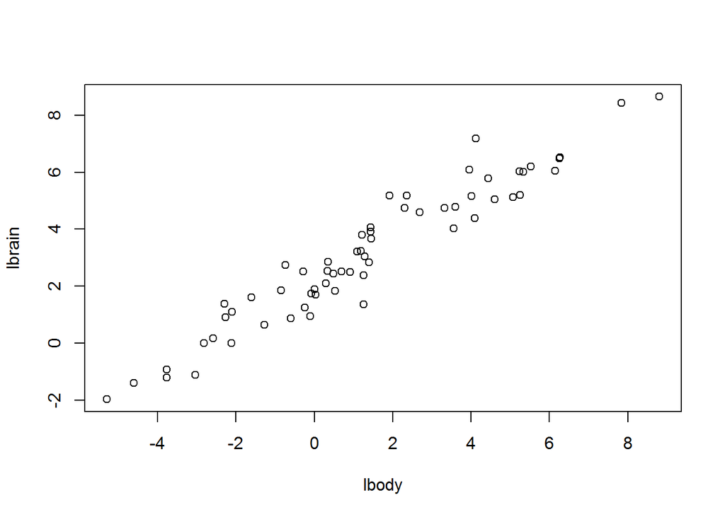

```r
lbrain <- log(brain)
lbody <- log(body)
plot(lbrain ~ lbody)
```

Wow, this is crying out for linear regression; let’s do it.

Linear regression model: y = a + b*x + Normally distributed “errors”

```r
lm1 <- lm(lbrain ~ lbody)
lm1
```

```
##
## Call:
## lm(formula = lbrain ~ lbody)
##
## Coefficients:
## (Intercept)        lbody
##      2.1348       0.7517
```

```r
summary(lm1)
```

```
##
## Call:
## lm(formula = lbrain ~ lbody)
##
## Residuals:
##      Min       1Q   Median       3Q      Max
## -1.71550 -0.49228 -0.06162  0.43597  1.94829
##
## Coefficients:
##             Estimate Std. Error t value Pr(>|t|)
## (Intercept)  2.13479    0.09604   22.23   <2e-16 ***
## lbody        0.75169    0.02846   26.41   <2e-16 ***
## ---
## Signif. codes:  0 '***' 0.001 '**' 0.01 '*' 0.05 '.' 0.1 ' ' 1
##
## Residual standard error: 0.6943 on 60 degrees of freedom
## Multiple R-squared:  0.9208, Adjusted R-squared:  0.9195
## F-statistic: 697.4 on 1 and 60 DF,  p-value: < 2.2e-16
```

```r
abline(lm1)
```

```
## Error in int_abline(a = a, b = b, h = h, v = v, untf = untf, ...): plot.new has not been called yet
```

```r
names(lm1)
```

```
##  [1] "coefficients"  "residuals"     "effects"       "rank"
##  [5] "fitted.values" "assign"        "qr"            "df.residual"
##  [9] "xlevels"       "call"          "terms"         "model"
```

```r
sort(lm1$residuals)
```

```
##             Water opossum                    Tenrec
##              -1.715496428              -1.100079214
##                Musk shrew                       Pig
##              -0.960916163              -0.893817157
##           Brazilian tapir           Giant armadillo
##              -0.819826743              -0.818000748
##           Desert hedgehog                  Kangaroo
##              -0.809934274              -0.781942122
##                       Cow         European hedgehog
##              -0.704299635              -0.700063920
##     Nine-banded armadillo              N.A. opossum
##              -0.696926847              -0.693104837
##            Golden hamster                    Jaguar
##              -0.541016395              -0.540184534
##                       Rat             Big brown bat
##              -0.536064395              -0.503205892
##                Guinea pig     Yellow-bellied marmot
##              -0.459522243              -0.352971141
##                     Horse    Arctic ground squirrel
##              -0.352512768              -0.331645719
##                    Rabbit                   Giraffe
##              -0.330346081              -0.326509689
##           Mountain beaver African giant pouched rat
##              -0.268509017              -0.247719028
##                     Mouse                Tree hyrax
##              -0.215523820              -0.146218402
##                   Gorilla Lesser short-tailed shrew
##              -0.136965236              -0.118230883
##          African elephant                     Okapi
##              -0.101535517              -0.090787805
##                 Phalanger          Little brown bat
##              -0.063808273              -0.059441375
##              Rock hyrax-b                 Grey wolf
##              -0.053126196              -0.052012159
##                    Donkey           Star-nosed mole
##              -0.029470399              -0.019987408
##          E. American mole                     Sheep
##              -0.005399721               0.010938666
##                      Goat                Slow loris
##               0.114555670               0.138018519
##                       Cat                   Echidna
##               0.210348946               0.258275741
##                 Grey seal                Chinchilla
##               0.309558036               0.364701495
##            Asian elephant                  Roe deer
##               0.404449017               0.425182038
##                   Raccoon                     Genet
##               0.439568332               0.469140656
##                Tree shrew                  Mole rat
##               0.482841228               0.545171049
##              Rock hyrax-a                    Galago
##               0.591057154               0.684441080
##                   Red fox                Arctic fox
##               0.700231550               0.744129330
##                    Verbet              Patas monkey
##               0.848713341               0.879322620
##           Ground squirrel                Chimpanzee
##               0.974846992               0.979582387
##                Owl monkey                    Baboon
##               1.157765654               1.284319858
##             Rhesus monkey                     Human
##               1.611673361               1.948289465
```

So residuals from a linear regression using the log transformation (which was suggested as a good thing to do by looking at the scatterplot) gives quite a meaningful “ranking” of species. Here we are looking at brain mass in terms of how much it is above or below what is expected (from the linear model) given body mass.

## Multiple regression with body fat data

Accurate measurements of body fat percentage (“bf”) involve submerging a person in water. How well can we “predict” (guess) a person’s bf using other easily measured quantities? In class we saw some dramatic footage of Australian people doing this.

```r
b <- read.csv("http://www.stat.yale.edu/~jtc5/STAT230/data/bodyfat.csv")
dim(b)
```

```
## [1] 250  14
```

```r
names(b)
```

```
##  [1] "bf"      "age"     "weight"  "height"  "neck"    "chest"   "abdomen"
##  [8] "hip"     "thigh"   "knee"    "ankle"   "bicep"   "forearm" "wrist"
```

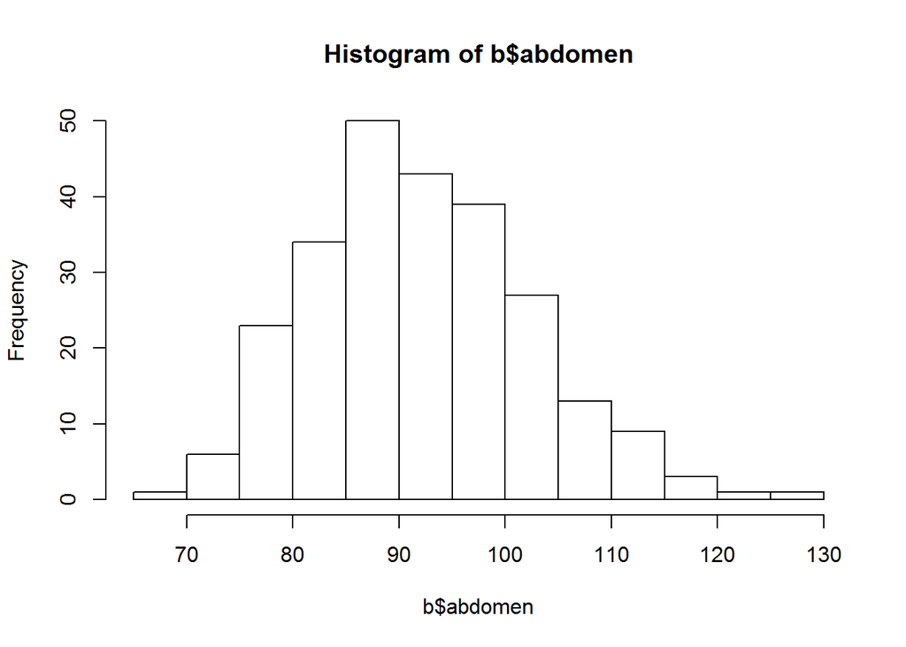

```r
hist(b$abdomen)
```

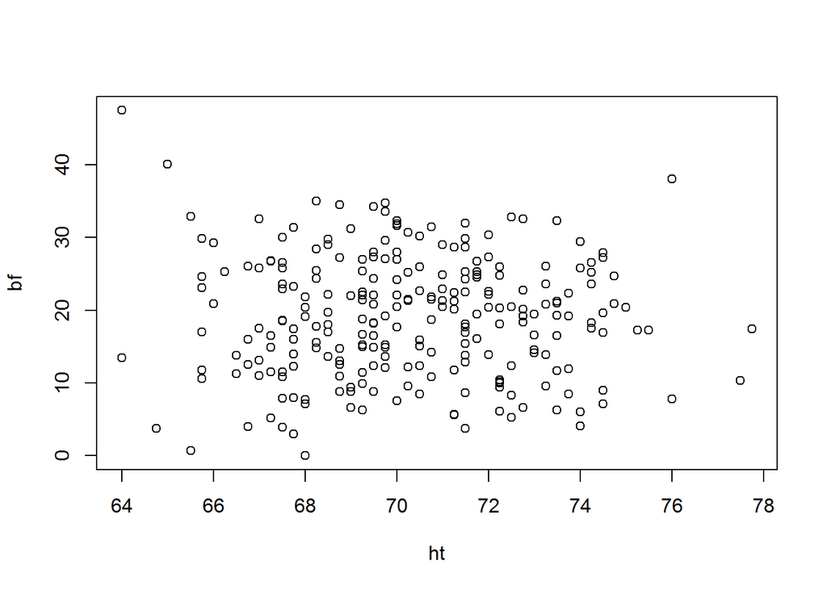

```r
bf <- b$bf
ht <- b$height
ab <- b$abdomen/2.54

plot(bf ~ ht)
```

```r
lmh <- lm(bf ~ ht)
summary(lmh)
```

```
##
## Call:
## lm(formula = bf ~ ht)
##
## Residuals:
##      Min       1Q   Median       3Q      Max
## -19.2461  -6.6605   0.2566   6.1433  27.8812
##
## Coefficients:
##             Estimate Std. Error t value Pr(>|t|)
## (Intercept) 25.58078   14.15400   1.807   0.0719 .
## ht          -0.09316    0.20119  -0.463   0.6438
## ---
## Signif. codes:  0 '***' 0.001 '**' 0.01 '*' 0.05 '.' 0.1 ' ' 1
##
## Residual standard error: 8.307 on 248 degrees of freedom
## Multiple R-squared:  0.0008637,  Adjusted R-squared:  -0.003165
## F-statistic: 0.2144 on 1 and 248 DF,  p-value: 0.6438
```

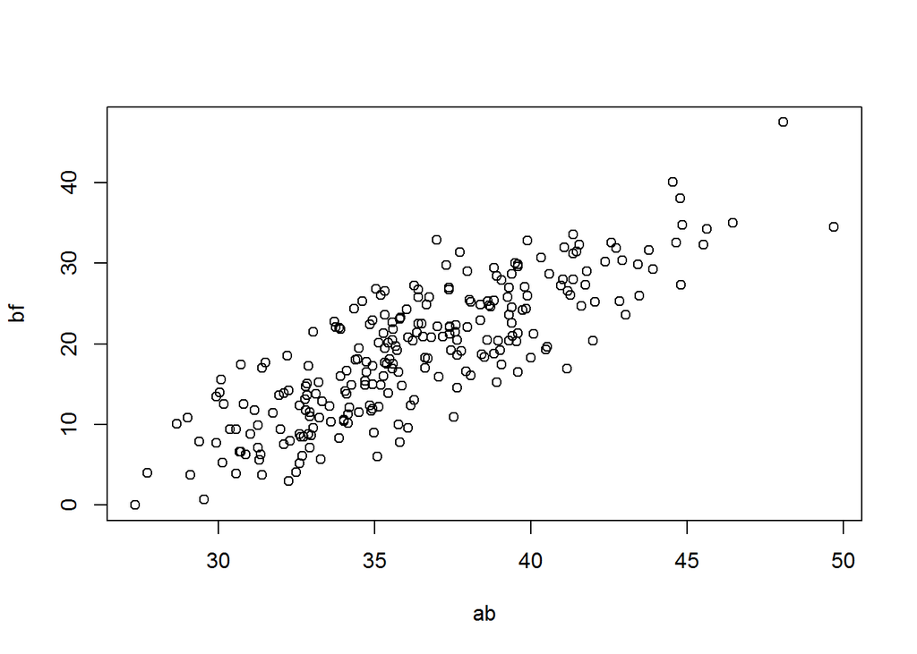

```r
plot(bf ~ ab)
```

```r
lma <- lm(bf ~ ab)
summary(lma)
```

```
##
## Call:
## lm(formula = bf ~ ab)
##
## Residuals:
##      Min       1Q   Median       3Q      Max
## -10.8987  -3.6453   0.1864   3.1775  12.7887
##
## Coefficients:
##              Estimate Std. Error t value Pr(>|t|)
## (Intercept) -42.73413    2.71651  -15.73   <2e-16 ***
## ab            1.69997    0.07431   22.88   <2e-16 ***
## ---
## Signif. codes:  0 '***' 0.001 '**' 0.01 '*' 0.05 '.' 0.1 ' ' 1
##
## Residual standard error: 4.713 on 248 degrees of freedom
## Multiple R-squared:  0.6785, Adjusted R-squared:  0.6772
## F-statistic: 523.3 on 1 and 248 DF,  p-value: < 2.2e-16
```

```r
lmha <- lm(bf ~ ht + ab)
summary(lmha)
```

```
##
## Call:
## lm(formula = bf ~ ht + ab)
##
## Residuals:
##      Min       1Q   Median       3Q      Max
## -11.1692  -3.4133  -0.0977   3.0995   9.9082
##
## Coefficients:
##             Estimate Std. Error t value Pr(>|t|)
## (Intercept) -3.10088    7.68611  -0.403    0.687
## ht          -0.60154    0.10994  -5.472 1.09e-07 ***
## ab           1.77309    0.07158  24.770  < 2e-16 ***
## ---
## Signif. codes:  0 '***' 0.001 '**' 0.01 '*' 0.05 '.' 0.1 ' ' 1
##
## Residual standard error: 4.46 on 247 degrees of freedom
## Multiple R-squared:  0.7132, Adjusted R-squared:  0.7109
## F-statistic: 307.1 on 2 and 247 DF,  p-value: < 2.2e-16
```

```r
summary(lma)
```

```
##
## Call:
## lm(formula = bf ~ ab)
##
## Residuals:
##      Min       1Q   Median       3Q      Max
## -10.8987  -3.6453   0.1864   3.1775  12.7887
##
## Coefficients:
##              Estimate Std. Error t value Pr(>|t|)
## (Intercept) -42.73413    2.71651  -15.73   <2e-16 ***
## ab            1.69997    0.07431   22.88   <2e-16 ***
## ---
## Signif. codes:  0 '***' 0.001 '**' 0.01 '*' 0.05 '.' 0.1 ' ' 1
##
## Residual standard error: 4.713 on 248 degrees of freedom
## Multiple R-squared:  0.6785, Adjusted R-squared:  0.6772
## F-statistic: 523.3 on 1 and 248 DF,  p-value: < 2.2e-16
```

The moral of this story so far is: in multiple regression the significance and utility of a variable “x” in predicting a variable “y” depends on what other explanatory variables are included in the model!